# ST558 Porject 1: Part 3

Bridget Knapp and Chien-Lan Hsueh

2022-07-09

## Summarizations

```r
# check balance - compare ecdf of train and test sets
plot(ecdf(df_train$shares), col = "blue", main = "Empirical Cumulative Distribution", xlab = "shares")
plot(ecdf(df_test$shares), col = "red", add = T)
```

[output not shown]

```r
# subset by channel
df_train_x <- df_train %>% filter(channel == params$channel)
df_train_x
```

| shares | channel | weekday | is_weekend | n_tokens_title | n_tokens_content | n_unique_tokens | n_non_stop_words | n_non_stop_unique_tokens | num_hrefs | num_self_hrefs | num_imgs | num_videos | average_token_length | num_keywords | kw_min_min | kw_max_min | kw_avg_min | kw_min_max | kw_max_max | kw_avg_max | kw_min_avg | kw_max_avg | kw_avg_avg | self_reference_min_shares | self_reference_max_shares | self_reference_avg_sharess | LDA_00 | LDA_01 | LDA_02 | … |
| --- | --- | --- | --- | --- | --- | --- | --- | --- | --- | --- | --- | --- | --- | --- | --- | --- | --- | --- | --- | --- | --- | --- | --- | --- | --- | --- | --- | --- | --- | --- |
| 556 | lifestyle | monday | N | 8 | 960 | 0.4181626 | 1 | 0.5498339 | 21 | 20 | 20 | 0 | 4.654167 | 10 | 0 | 0 | 0.00000 | 0 | 0 | 0.000 | 0.0000 | 0.000 | 0.0000 | 545 | 16000 | 3151.158 | 0.02008167 | 0.11470539 | 0.02002437 | … |
| 5700 | lifestyle | monday | N | 11 | 103 | 0.6893204 | 1 | 0.8064516 | 3 | 1 | 1 | 0 | 4.844660 | 6 | 0 | 0 | 0.00000 | 0 | 0 | 0.000 | 0.0000 | 0.000 | 0.0000 | 5000 | 5000 | 5000.000 | 0.43737358 | 0.20036349 | 0.03345679 | … |
| 462 | lifestyle | monday | N | 10 | 243 | 0.6192469 | 1 | 0.8244275 | 1 | 1 | 0 | 0 | 4.382716 | 10 | 0 | 0 | 0.00000 | 0 | 0 | 0.000 | 0.0000 | 0.000 | 0.0000 | 0 | 0 | 0.000 | 0.02004090 | 0.02003078 | 0.02001470 | … |
| 3600 | lifestyle | monday | N | 8 | 204 | 0.5862069 | 1 | 0.6984127 | 7 | 2 | 1 | 0 | 4.671569 | 8 | 0 | 0 | 0.00000 | 0 | 0 | 0.000 | 0.0000 | 0.000 | 0.0000 | 0 | 0 | 0.000 | 0.21146955 | 0.02550736 | 0.02514117 | … |
| 343 | lifestyle | monday | N | 11 | 315 | 0.5512820 | 1 | 0.7022472 | 4 | 4 | 1 | 0 | 4.380952 | 10 | 0 | 0 | 0.00000 | 0 | 0 | 0.000 | 0.0000 | 0.000 | 0.0000 | 6200 | 6200 | 6200.000 | 0.02008707 | 0.02063128 | 0.02051673 | … |
| 552 | lifestyle | monday | N | 6 | 374 | 0.6405405 | 1 | 0.8280543 | 7 | 0 | 1 | 0 | 4.909091 | 8 | 0 | 0 | 0.00000 | 0 | 0 | 0.000 | 0.0000 | 0.000 | 0.0000 | 0 | 0 | 0.000 | 0.20664598 | 0.14609471 | 0.27602544 | … |
| 1200 | lifestyle | tuesday | N | 12 | 499 | 0.5130261 | 1 | 0.6622517 | 14 | 1 | 1 | 0 | 5.084168 | 10 | 217 | 1500 | 581.40000 | 0 | 17100 | 3460.000 | 0.0000 | 2193.250 | 884.8520 | 1300 | 1300 | 1300.000 | 0.02024897 | 0.13282205 | 0.12026710 | … |
| 1200 | lifestyle | wednesday | N | 11 | 1099 | 0.4123049 | 1 | 0.5573770 | 28 | 24 | 20 | 0 | 4.583258 | 10 | 217 | 823 | 339.57143 | 0 | 17100 | 8262.300 | 0.0000 | 2011.393 | 1159.5600 | 545 | 16000 | 3151.158 | 0.02003214 | 0.11498601 | 0.02008995 | … |
| 2300 | lifestyle | wednesday | N | 9 | 455 | 0.4955947 | 1 | 0.6590038 | 10 | 5 | 1 | 0 | 4.694505 | 9 | 217 | 2600 | 1095.50000 | 0 | 17100 | 3880.333 | 0.0000 | 3600.000 | 1366.7938 | 2000 | 4900 | 3500.000 | 0.15501580 | 0.02231451 | 0.15879565 | … |
| 752 | lifestyle | wednesday | N | 10 | 258 | 0.5891473 | 1 | 0.7371795 | 2 | 1 | 11 | 0 | 4.852713 | 9 | 217 | 695 | 373.28571 | 0 | 17100 | 6266.667 | 0.0000 | 2239.333 | 1222.8899 | 0 | 0 | 0.000 | 0.02230278 | 0.38129625 | 0.02225418 | … |

[output cut: 990 more lines]

```r
df_test_x <- df_test %>% filter(channel == params$channel)
```

# Exploratory Data Analysis

```r
library(vtable)
st(df_train_x)
```

[output not shown]

Next, lets learn more about our response variable: `shares`. Lets do a 5-number summary. It will show the minimum (Min.), first quartile (1st Qu.), median (Median), mean (Mean), third quartile (3rd Qu.), and maximum (Max.). This will help us get an idea about the overall spread of the `shares` data.

```r
nrow(df_train_x)
```

```
[1] 1464
```

```r
summary(df_train_x$shares)
```

```
   Min. 1st Qu.  Median    Mean 3rd Qu.    Max.
     28    1100    1700    3634    3200  208300
```

Next, lets plot a histogram of the `shares` data so that we can visually see it’s distribution. For example, we can determine if the distribution of `shares` is symmetric, skewed left, or skewed right.

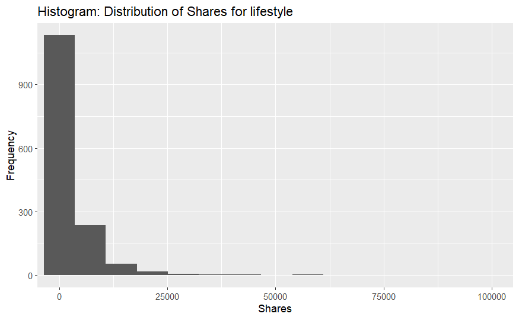

```r
df_train_x %>%
  ggplot(aes(x = shares)) +
  geom_histogram() +
  labs(
    title = paste0("Histogram: Distribution of Shares for ", params$channel),
    y="Frequency",
    x="Shares") +
  coord_cartesian(xlim = c(0,100000))
```

Next, we’ll create a box plot. Before we do that, let’s make a binary version of the `shares` data. Using the median of the `shares` data, we will give entries with a number of shares >= the median a 1 and the rest a 0. I chose to use the median because it is not affected by outliers, which is an advantage when dealing with skewed distributions. This plot will show if the majority of shares is greater than or less than the median of the shares. If it’s larger than the median, the box plot over the 1 should be larger and more spread out than the one over the 0. I did a log transformation on our data because it will make our skewed data more normal.

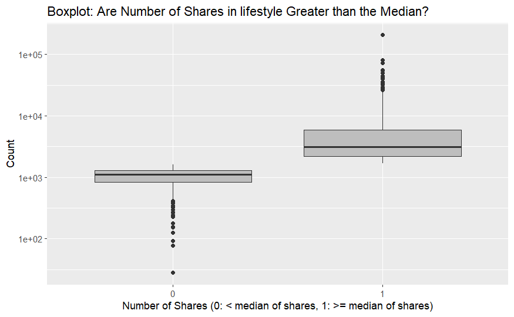

```r
library(tidyverse)
binary <- function(S){
if(S>=median(df_train_x$shares,na.rm = TRUE)){
A<-1
return(A)
}
if(S<median(df_train_x$shares,na.rm = TRUE)){
A<-0
return(A)
}
}

df_train_x$binary_shares <- as.numeric(sapply(df_train_x$shares, FUN=binary))
ggplot(df_train_x, aes(x = factor(binary_shares), y = shares)) +
geom_boxplot(fill = "grey") +
  scale_y_log10() +
  labs(x="Number of Shares (0: < median of shares, 1: >= median of shares)",
       title=paste0("Boxplot: Are Number of Shares in ",params$channel," Greater than the Median?"),
       y="Count")
```

Now, let’s summarize the rest of the numeric variables (i.e., not `channel`,`weekday`,`is_weekend` because they’re factors). This will give the 5-number summary for all of the numeric variables in our data set. This can help us understand the distribution of each variable.

```r
df_train_x %>%
  select(-c(channel,weekday,is_weekend)) %>%
  summary()
```

```
     shares       n_tokens_title   n_tokens_content n_unique_tokens  n_non_stop_words
 Min.   :    28   Min.   : 3.000   Min.   :   0.0   Min.   :0.0000   Min.   :0.0000
 1st Qu.:  1100   1st Qu.: 8.000   1st Qu.: 299.0   1st Qu.:0.4634   1st Qu.:1.0000
 Median :  1700   Median :10.000   Median : 498.0   Median :0.5221   Median :1.0000
 Mean   :  3634   Mean   : 9.755   Mean   : 621.7   Mean   :0.5263   Mean   :0.9911
 3rd Qu.:  3200   3rd Qu.:11.000   3rd Qu.: 799.5   3rd Qu.:0.5929   3rd Qu.:1.0000
 Max.   :208300   Max.   :18.000   Max.   :8474.0   Max.   :0.8681   Max.   :1.0000
 n_non_stop_unique_tokens   num_hrefs      num_self_hrefs     num_imgs         num_videos
 Min.   :0.0000           Min.   :  0.00   Min.   : 0.00   Min.   :  0.000   Min.   : 0.0000
 1st Qu.:0.6274           1st Qu.:  6.00   1st Qu.: 1.00   1st Qu.:  1.000   1st Qu.: 0.0000
 Median :0.6844           Median : 10.00   Median : 2.00   Median :  1.000   Median : 0.0000
 Mean   :0.6858           Mean   : 13.33   Mean   : 2.51   Mean   :  4.844   Mean   : 0.4563
 3rd Qu.:0.7544           3rd Qu.: 18.00   3rd Qu.: 3.00   3rd Qu.:  8.000   3rd Qu.: 0.0000
 Max.   :1.0000           Max.   :145.00   Max.   :40.00   Max.   :111.000   Max.   :50.0000
 average_token_length  num_keywords      kw_min_min       kw_max_min        kw_avg_min
 Min.   :0.000        Min.   : 3.000   Min.   : -1.00   Min.   :    0.0   Min.   :   -1.0
 1st Qu.:4.447        1st Qu.: 7.000   1st Qu.: -1.00   1st Qu.:  502.8   1st Qu.:  185.8
 Median :4.625        Median : 8.000   Median :  4.00   Median :  813.0   Median :  301.2
 Mean   :4.598        Mean   : 8.245   Mean   : 40.21   Mean   : 1724.8   Mean   :  426.1
 3rd Qu.:4.793        3rd Qu.:10.000   3rd Qu.:  4.00   3rd Qu.: 1300.0   3rd Qu.:  446.9
 Max.   :5.947        Max.   :10.000   Max.   :377.00   Max.   :98700.0   Max.   :14187.8
   kw_min_max       kw_max_max       kw_avg_max       kw_min_avg     kw_max_avg      kw_avg_avg
 Min.   :     0   Min.   :     0   Min.   :     0   Min.   :   0   Min.   :    0   Min.   :    0
 1st Qu.:     0   1st Qu.:690400   1st Qu.:118397   1st Qu.:   0   1st Qu.: 4087   1st Qu.: 2640
 Median :     0   Median :843300   Median :182396   Median :   0   Median : 5062   Median : 3253
 Mean   :  7249   Mean   :704618   Mean   :183678   Mean   :1063   Mean   : 6820   Mean   : 3435
 3rd Qu.:  6200   3rd Qu.:843300   3rd Qu.:250477   3rd Qu.:2299   3rd Qu.: 7344   3rd Qu.: 3946
 Max.   :208300   Max.   :843300   Max.   :538744   Max.   :3610   Max.   :98700   Max.   :20378
 self_reference_min_shares self_reference_max_shares self_reference_avg_sharess     LDA_00
 Min.   :     0.0          Min.   :     0.0          Min.   :     0.0           Min.   :0.01818
 1st Qu.:   600.8          1st Qu.:   881.8          1st Qu.:   881.8           1st Qu.:0.02249
 Median :  1600.0          Median :  2800.0          Median :  2500.0           Median :0.02912
 Mean   :  4761.4          Mean   :  8605.0          Mean   :  6385.3           Mean   :0.17265
 3rd Qu.:  3800.0          3rd Qu.:  7400.0          3rd Qu.:  5700.0           3rd Qu.:0.22890
 Max.   :144900.0          Max.   :690400.0          Max.   :401450.0           Max.   :0.91980
     LDA_01            LDA_02            LDA_03            LDA_04        global_subjectivity
 Min.   :0.01819   Min.   :0.01819   Min.   :0.01820   Min.   :0.02014   Min.   :0.0000
 1st Qu.:0.02071   1st Qu.:0.02222   1st Qu.:0.02247   1st Qu.:0.31849   1st Qu.:0.4241
 Median :0.02507   Median :0.02587   Median :0.03336   Median :0.57454   Median :0.4753
 Mean   :0.06465   Mean   :0.08027   Mean   :0.14894   Mean   :0.53349   Mean   :0.4724
```

[output cut: 22 more lines]

```
 Max.   :1.0000        Max.   : 0.0000       Max.   : 0.0000       Max.   : 0.0000
 title_subjectivity title_sentiment_polarity abs_title_subjectivity abs_title_sentiment_polarity
 Min.   :0.0000     Min.   :-1.0000          Min.   :0.0000         Min.   :0.0000
 1st Qu.:0.0000     1st Qu.: 0.0000          1st Qu.:0.1676         1st Qu.:0.0000
 Median :0.1000     Median : 0.0000          Median :0.5000         Median :0.0000
 Mean   :0.2836     Mean   : 0.1064          Mean   :0.3490         Mean   :0.1714
 3rd Qu.:0.5000     3rd Qu.: 0.2000          3rd Qu.:0.5000         3rd Qu.:0.2670
 Max.   :1.0000     Max.   : 1.0000          Max.   :0.5000         Max.   :1.0000
 binary_shares
 Min.   :0.0000
 1st Qu.:0.0000
 Median :1.0000
 Mean   :0.5082
 3rd Qu.:1.0000
 Max.   :1.0000
```

We can also visually inspect the distribution of each variable by making a histogram for each. We can look at each variable and see if it has a symmetric, skewed left, or skewed right distribution.

```
click left mouse button to proceed
```

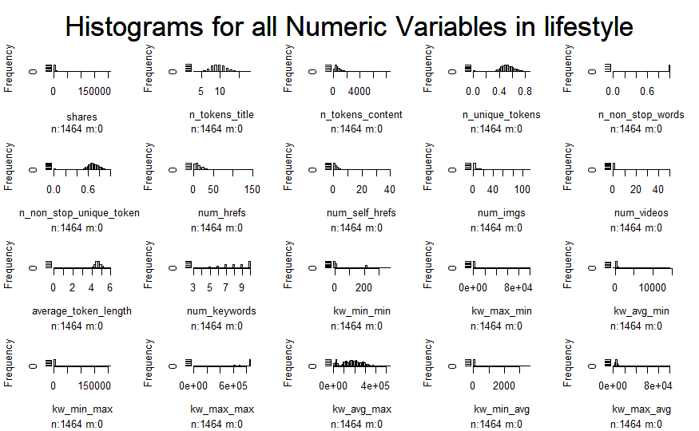

```
click left mouse button to proceed
```

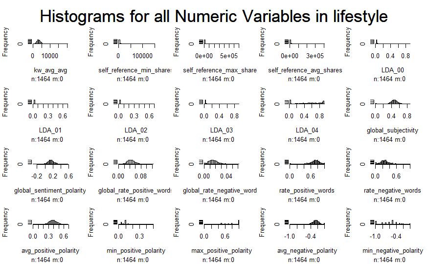

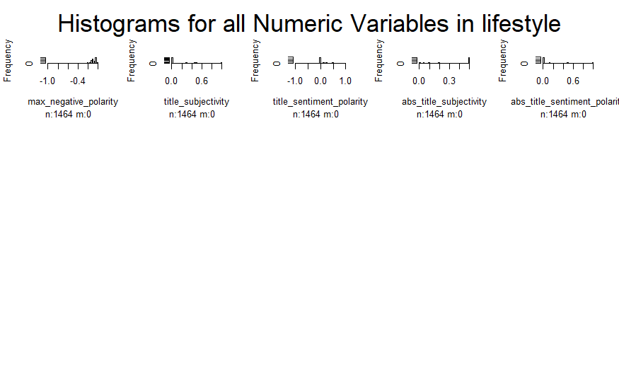

```r
library(Hmisc)
df_train_x %>%
  select(-c(channel,weekday,is_weekend)) %>%
  hist.data.frame(mtitl=paste0("Histograms for all Numeric Variables in ",params$channel))
```

Now, we will make a correlation plot comparing all of our numeric variables. When we do our modeling, we’re looking for correlations that are greater than 0.75 and less than -0.75. In the plot below, we are looking for the bright red and bright blue sections.

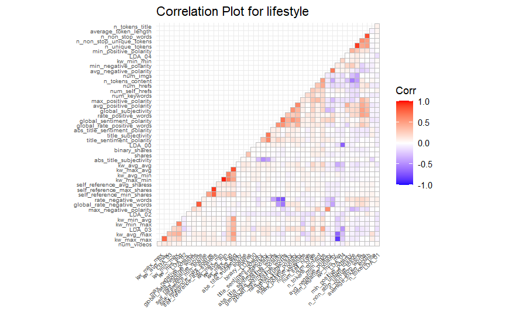

```r
df_train_x_v1 <- dplyr::select_if(df_train_x, is.numeric) #trying not to overwrite df_train_x

r <- cor(df_train_x_v1, use="complete.obs")
library(ggplot2)
library(ggcorrplot)
ggcorrplot(r,
           hc.order = TRUE,
           type = "lower",
           tl.cex = 6,
           title = paste0("Correlation Plot for ",params$channel))
```

```r
df_train_x %>%
  select(weekday, is_weekend) %>%
  summary()
```

```
      weekday    is_weekend
 sunday   :149   N:1193
 monday   :225   Y: 271
 tuesday  :230
 wednesday:277
 thursday :261
 friday   :200
 saturday :122
```

Below is a box plot showing the number of shares for each weekday. I did a log transformation on our data because it will make our skewed data more normal. It will help us understand if there are certain days of the week where articles get more or less shares.

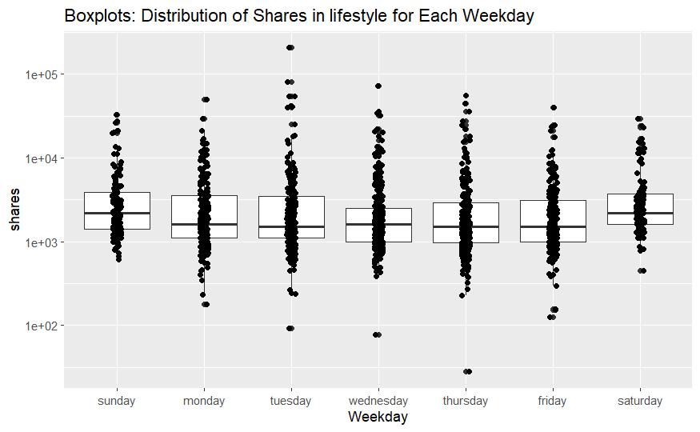

```r
df_train_x %>%
  select(weekday,is_weekend,shares) %>%
  ggplot(aes(weekday, shares)) +
geom_boxplot() +
  scale_y_log10() +
geom_jitter(width = 0.05) +
labs(
  title = paste0("Boxplots: Distribution of Shares in ",params$channel," for Each Weekday"),
  x = "Weekday"
)
```